# Draft Analysis for Married Family & Family Income

Yicheng Wang, Arnold Lau

January 31, 2016

# 1 Preparation

```r
library("survey")
library("dplyr")
library("data.table")
library("ggplot2")
library("choroplethr")
library("choroplethrMaps")
```

```r
source("../lib/readIn.R")
hus <- readIn_house(TRUE, pathA = "../../ss13husa.csv", pathB = "../../ss13husb.csv", save = FALSE)
```

```
##
Read 0.0% of 756065 rows
Read 15.9% of 756065 rows
Read 31.7% of 756065 rows
Read 47.6% of 756065 rows
Read 62.2% of 756065 rows
Read 78.0% of 756065 rows
Read 92.6% of 756065 rows
Read 756065 rows and 231 (of 231) columns from 0.574 GB file in 00:00:12
##
Read 0.0% of 720248 rows
Read 13.9% of 720248 rows
Read 26.4% of 720248 rows
Read 41.7% of 720248 rows
Read 56.9% of 720248 rows
Read 72.2% of 720248 rows
Read 83.3% of 720248 rows
Read 93.0% of 720248 rows
Read 720248 rows and 231 (of 231) columns from 0.546 GB file in 00:00:12
```

```r
weights <- select(hus, WGTP)
repweights <- select(hus, starts_with("wgtp"), -WGTP)
# Specify the sampling design structure using the replicate weights
design <- svrepdesign(data = hus, repweights = repweights, weights = weights, type = "BRR",
                      combined.weights = TRUE)
rm(weights, repweights)
```

There are a total of 1,476,313 households in the dataset. In this analysis we focus on a subset of the households via the variable **FES** (Family Type and Employment Status), looking only at married-couple families.

```r
table(hus$FES, useNA = "ifany")
```

```
##
##      1      2      3      4      5      6      7      8   <NA>
## 308001 133567  52764 122758  38069  13022  94629  46556 666947
```

```r
sum(table(hus$FES)[1:4])
```

```
## [1] 617090
```

There are 666,947 missing values in **FES** in the sample, and our subset will have 617,090 families. We can also get an estimate of the total number of households this represents in the entire U.S:

```r
hus$FES_CAT <- as.factor(hus$FES)
# Get the population estimate for the total number of households by FES
fes_popest <- as.data.frame(svytotal(~hus$FES_CAT, design = design, na.rm = TRUE))
fes_popest <- cbind(fes_popest, FES = c(1:8))
fes_popest
```

```
##                 total        SE FES
## hus$FES_CAT1 28870524 27239.905   1
## hus$FES_CAT2 12471550 19568.649   2
## hus$FES_CAT3  4460675 12956.437   3
## hus$FES_CAT4  9830047 14871.015   4
## hus$FES_CAT5  4366996 12299.732   5
## hus$FES_CAT6  1238745  6441.148   6
## hus$FES_CAT7 10735925 18305.325   7
## hus$FES_CAT8  4493758 12947.012   8
```

```r
hus <- tbl_df(hus)
hus_subset <- hus %>% select(FES, FES_CAT, FINCP, ST) %>% filter(FES %in% c(1:4)) %>% group_by(FES)
hus_subset$FES_CAT <- droplevels(hus_subset$FES_CAT)
```

# 2 Visualization

```r
fescode <- "FES,MarriedFamilyEmployType
              1,Both in Labor Force
              2,Husband in Labor Force
              3,Wife in Labor Force
              4,Neither in Labor Force"
fescodes <- fread(fescode)

fesnumbers <- summarise(hus_subset,count=n())
fesnumbers <- left_join(fesnumbers,fescodes,by.x=c("FES"))
fesnumbers <- left_join(fesnumbers, fes_popest, by.x = c("FES"))
fesnumbers <- mutate(fesnumbers, samp_percent = (count / sum(fesnumbers$count)) * 100,
                                 pop_percent = (total / sum(fesnumbers$total)) * 100)
Types <- factor(fesnumbers$MarriedFamilyEmployType,levels=unique(fesnumbers$MarriedFamilyEmployType))
```

## 2.1 Descriptive Statistics

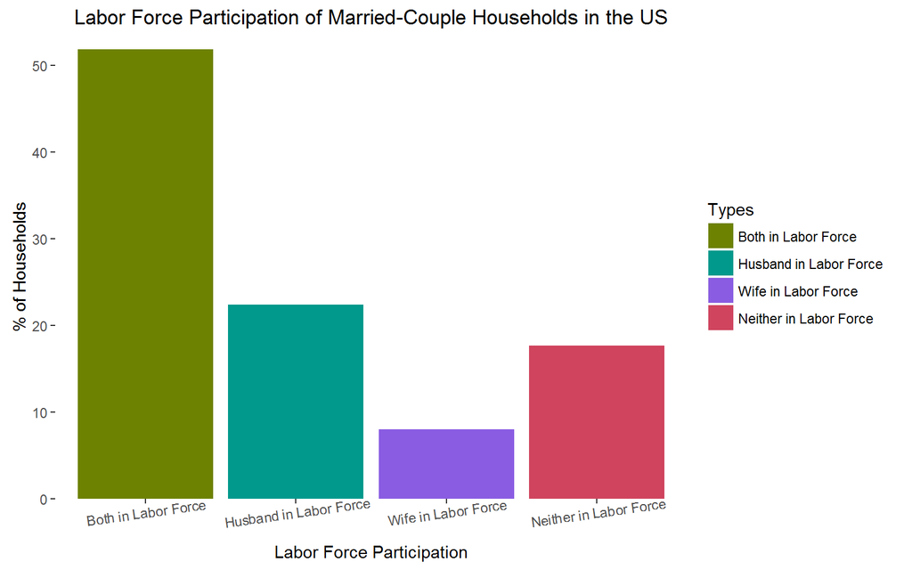

```r
options(scipen = 999) # display digits instead of scientific notation
ggplot(fesnumbers, aes(x = Types, y = fesnumbers$pop_percent, fill = Types)) +
       geom_bar(stat="identity") + scale_fill_hue(l=50, h.start = 80) +
       ylab("% of Households") +
       xlab("Labor Force Participation") +
       ggtitle("Labor Force Participation of Married-Couple Households in the US") +
       theme(axis.text.x = element_text(angle = 8, hjust = 0.5),
       panel.background = element_rect(fill = 'white')) +
       scale_y_discrete(breaks = seq(0, 100, 10))
```

Looking at estimated population percentages for family type and employment status among married couples, we see that just over 50% of married-couple households have both husband and wife in the labor force, compared to around 22% with only the husband in the labor force, 8% with only the wife in the labor force, and 18% with neither the husband nor the wife in the labor force, which may indicate retired couples.

```r
hus_subset$FINCP_ADJ <- hus_subset$FINCP * 1.007549 # adjusts reported income to 2013 dollars
summary(hus_subset$FINCP_ADJ)
```

```
##    Min. 1st Qu.  Median    Mean 3rd Qu.    Max.
##  -19920   46150   77580  101400  122100 2076000
```

The median family income in the sample is $77,580. (This is different from household income, where a household might consist of multiple families or multiple unrelated people living together.) Is there a difference in labor force participation between households at or above median income vs. below? Under the unlikely theory that family income has nothing to do with married-couple labor force participation, we would expect the proportion of each category for the “at or above median” vs. “below median” subgroups to be roughly the same as the general proportion.

```r
abovemedian <- hus_subset %>% filter(FINCP_ADJ >= 77580) %>% group_by(FES) %>% summarise(count = n())
abovemedian <- left_join(abovemedian, fescodes, by.x=c("FES"))
abovemedian <- mutate(abovemedian, percent = (count / sum(abovemedian$count)) * 100)

belowmedian <- hus_subset %>% filter(FINCP_ADJ < 77580) %>% group_by(FES) %>% summarise(count = n())
belowmedian <- left_join(belowmedian, fescodes, by.x=c("FES"))
belowmedian <- mutate(belowmedian, percent = (count / sum(belowmedian$count)) * 100)
```

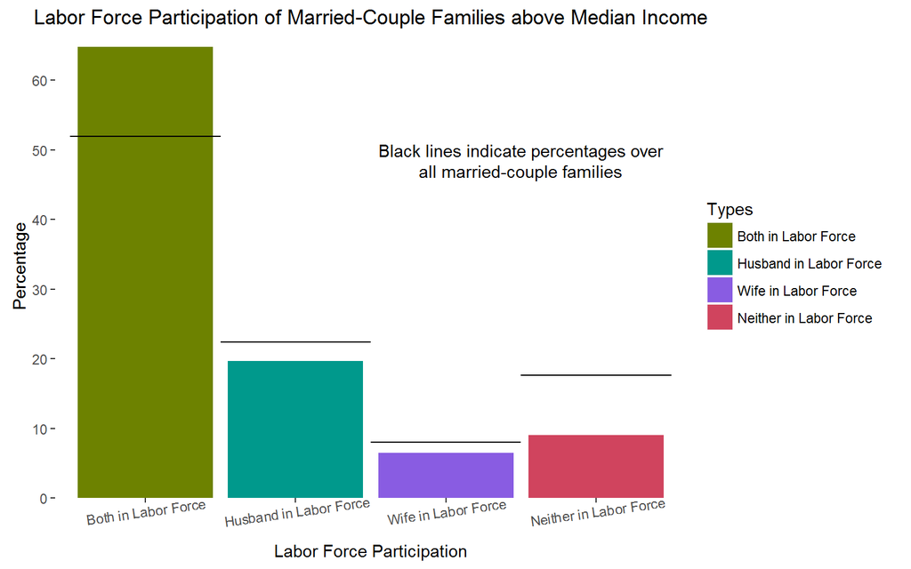

```r
ggplot(abovemedian, aes(x = Types, y = abovemedian$percent, fill = Types)) +
       geom_bar(stat="identity") + scale_fill_hue(l=50, h.start = 80) +
       geom_segment(aes(x = 0.5, y = fesnumbers$pop_percent[1],
                        xend = 1.5, yend = fesnumbers$pop_percent[1])) +
       geom_segment(aes(x = 1.5, y = fesnumbers$pop_percent[2],
                        xend = 2.5, yend = fesnumbers$pop_percent[2])) +
       geom_segment(aes(x = 2.5, y = fesnumbers$pop_percent[3],
                        xend = 3.5, yend = fesnumbers$pop_percent[3])) +
       geom_segment(aes(x = 3.5, y = fesnumbers$pop_percent[4],
                        xend = 4.5, yend = fesnumbers$pop_percent[4])) +
       ylab("Percentage") +
       xlab("Labor Force Participation") +
       ggtitle("Labor Force Participation of Married-Couple Families above Median Income")+
       theme(axis.text.x = element_text(angle = 8, hjust = 0.5),
       panel.background = element_rect(fill = 'white')) +
       scale_y_discrete(breaks = seq(0, 100, 10)) +
       annotate("text", x = 3.5, y = 50, label = "Black lines indicate percentages over") +
       annotate("text", x = 3.5, y = 47, label = "all married-couple families")
```

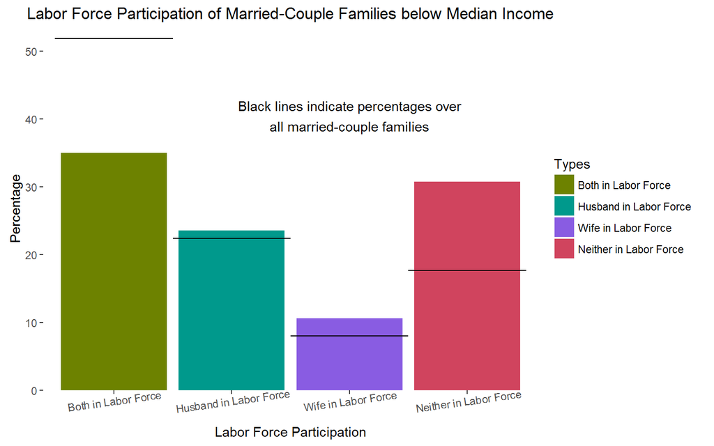

```r
ggplot(belowmedian, aes(x = Types , y = belowmedian$percent, fill = Types)) +
       geom_bar(stat="identity") + scale_fill_hue(l=50, h.start = 80) +
       geom_segment(aes(x = 0.5, y = fesnumbers$pop_percent[1],
                        xend = 1.5, yend = fesnumbers$pop_percent[1])) +
       geom_segment(aes(x = 1.5, y = fesnumbers$pop_percent[2],
                        xend = 2.5, yend = fesnumbers$pop_percent[2])) +
       geom_segment(aes(x = 2.5, y = fesnumbers$pop_percent[3],
                        xend = 3.5, yend = fesnumbers$pop_percent[3])) +
       geom_segment(aes(x = 3.5, y = fesnumbers$pop_percent[4],
                        xend = 4.5, yend = fesnumbers$pop_percent[4])) +
       ylab("Percentage") +
       xlab("Labor Force Participation") +
       ggtitle("Labor Force Participation of Married-Couple Families below Median Income")+
       theme(axis.text.x = element_text(angle = 8, hjust = 0.5),
       panel.background = element_rect(fill = 'white')) +
       scale_y_discrete(breaks = seq(0, 100, 10)) +
       annotate("text", x = 3, y = 42, label = "Black lines indicate percentages over") +
       annotate("text", x = 3, y = 39, label = "all married-couple families")
```

Comparing married-couple households at or above median income and married-couple households below median income, it appears that the biggest differences are in two-income vs no-income families. The percentage of single-earner families appears to be roughly the same in both groups, while there is a greater percentage of two-income families earning above median income and a greater percentage of no-income families earning below median income.

```r
statenames <- read.csv("../data/statenames.csv", strip.white = TRUE)
statenames <- rename(statenames, ST = code)
```

## 2.2 Choropleth Map

This map shows percentage of family which neither of the member is in the labor force while having more than $122100 (3rd quantile) family income.

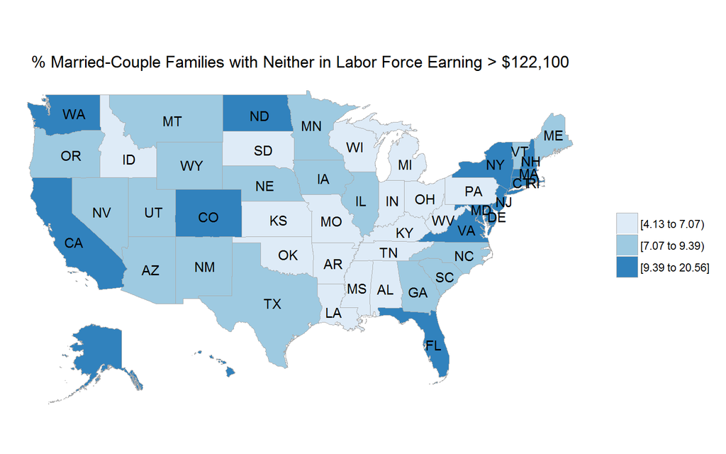

```r
stateTotalBoth <- hus_subset %>% filter(FES==4) %>% group_by(ST) %>% summarise(count=n())
medianBoth <- hus_subset %>% filter(FES==4, FINCP>= 122100) %>% group_by(ST) %>%    summarise(count=n())
medianBoth <- left_join(medianBoth, statenames)
medianBoth[is.na(medianBoth)] <- 0
medianBoth <- mutate(medianBoth,value=medianBoth$count/stateTotalBoth$count*100)
medianBoth <- rename(medianBoth, region = name)
medianBoth$region <- tolower(medianBoth$region)
state_choropleth(medianBoth,
         title = "% Married-Couple Families with Neither in Labor Force Earning > $122,100",
         num_colors = 3)
```